# 都道府県別データによる可視化

人口の例

[岩田真一郎](https://shinichiro-iwata.github.io/)（ [神奈川大学経済学部](https://www.econ.kanagawa-u.ac.jp/)）

2022-06-01作成，2025-01-10改訂

# 1 目的

[`NipponMap`](https://cran.r-project.org/web/packages/NipponMap/index.html)を活用して都道府県別データを日本地図に可視化．今回は人口を表現する．

パッケージ：`sf`，`tidyverse`，`Nipponmap`

- インストールしていないない**パッケージ**は”Packages … required but it is not installed. Install Don’t Show Again” と質問されるので，`Install`を選択．「…」はインストールしたいパッケージ名．
  - **パッケージ**：ある機能（データを操作する，図を描く）を実現するための関数群をまとめたもの．インストールして利用．
  - 仮に質問がない場合は，`#install.packages("...")`の`#`を削除し，インストール．「…」はインストールしたいパッケージ名．
  - インストールは一度だけでよいため，その後この`R`コードは削除可能．
- **ライブラリ**：パッケージがインストールされるフォルダ（ディレクトリ）のこと．`library(...)`でパッケージの読込．

```r
#install.packages("...")

library(sf)
library(tidyverse)
library(NipponMap)
```

# 2 データの読込と日本地図の可視化

**シェープファイル**

`NipponMap`がインストールできれば，シェープファイル（`shapes`）がユーザライブラリにある．[^1]このファイルを現在作業しているフォルダ（ディレクトリ）に移す．

- R > win-library > x.y （Rのバーション） > `NipponMap`
- `shapes`と示されるフォルダがあるので，これをコピーし， 現在作業しているフォルダにペーストする．
- **オブジェクト**を`Nippon_map`と名付け，`read_sf()`でデータを読込．
  - **オブジェクト**：データを表現するための基本構造．ベクトル，行列，データフレーム，リスト，ファクターなどの種類がある．`R`ではオブジェクトにデータを格納．
  - シェープファイルを現在のフォルダに移すのが面倒だと思う場合は，`Nippon_map<-`以降のコマンドを`read_sf(system.file("shapes/jpn.shp"), package="NipponMap")`にしても可能．この場合，移す作業は必要ない．
  - `crs="WGS84"`は削除しても目的は達成可能．`crs`（Coordinate Reference System，座標参照系）を1984年に定められた世界測地系（World Geodetic System）に投影を意味．

```r
Nippon_map<-read_sf("shapes/jpn.shp",
                    crs="WGS84")
```

**日本地図の可視化**

- `ggplot()`を用いて都道府県の境界が示された日本地図を可視化．
- `ggplot()`を用いた可視化に関しては，括弧内の示し方が何通りかあるが，このチュートリアルではできるだけ次のように統一．
  - `ggplot()`：括弧内記入なし．
  - `geom_sf()`：シェープファイルに含まれる図形（地物）・属性情報を可視化する関数．`data=Nippon_map`をデータとして利用するように指示．

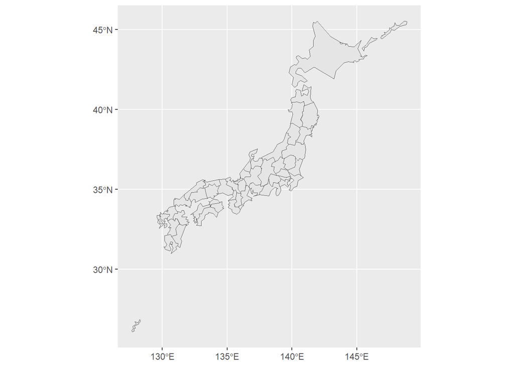

```r
ggplot()+
  geom_sf(data=Nippon_map)
```

# 3 都道府県別人口の可視化

**データの中身**

- `head()`を用いると`Nippon_map`の上から6行目までの中身が確認可能．
  - 人口（`population`）データが4列目に含まれていることがわかる．

```r
head(Nippon_map)
```

| SP_ID | jiscode | name | population | region | geometry |
| --- | --- | --- | --- | --- | --- |
| 1 | 01 | Hokkaido | 5506419 | Hokkaido | MULTIPOLYGON (((139.7707 42… |
| 2 | 02 | Aomori | 1373339 | Tohoku | MULTIPOLYGON (((140.8727 40… |
| 3 | 03 | Iwate | 1330147 | Tohoku | MULTIPOLYGON (((140.7862 39… |
| 4 | 04 | Miyagi | 2348165 | Tohoku | MULTIPOLYGON (((140.2802 38… |
| 5 | 05 | Akita | 1085997 | Tohoku | MULTIPOLYGON (((140.7895 39… |
| 6 | 06 | Yamagata | 1168924 | Tohoku | MULTIPOLYGON (((140.2802 38… |

**人口分布の可視化**

- `aes(fill=...)`：示したい変数「…」（数値データ）を指定．ここでは`population`を指定．`fill`は枠内の色．[^2]
  - `fill`を`color`にすると，枠線の色．枠内と枠線の色を両方指示することも可能．

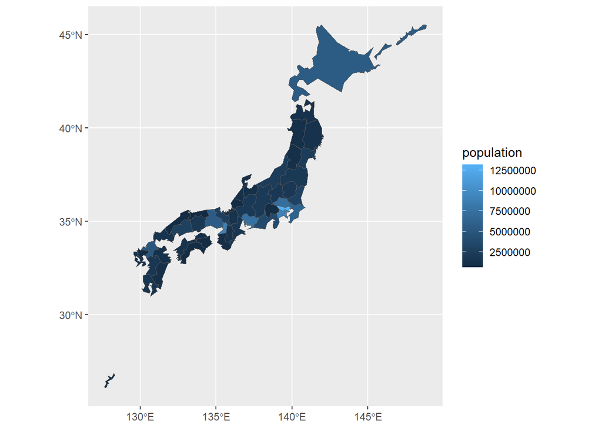

```r
ggplot()+
  geom_sf(data=Nippon_map, aes(fill=population))
```

最後に数値データの色を変更し，地図のタイトルをつけ，凡例を変更して，完成地図を示す．

- 色分けは`viridis`を利用．[^3][viridis](https://cran.r-project.org/web/packages/viridis/vignettes/intro-to-viridis.html)は視覚的に優れており，バリアフリー，白黒印刷にも対応可能．
  - `scale_fill_viridis_c()`：連続変数（`aes`内の`fill`）の色分けを指示する関数．`c`は連続変数
  - 数値データの色を`option="G"`とする．`option="mako"`に等しい．
  - `direction=-1`を用いて色の順番を逆にする．
  - `labs()`：凡例を「人」にするように指示．`aes`内の`fill=population`を「人」に変更している．
    - `caption`に出典を記す．図の右下に表示される．
  - `ggtilte()`：図のタイトルを指示する関数．
- `ggplot()`は初期設定のままの場合，背面（枠内）は灰色，線（枠）は白で描写（`theme_grey()`）.`theme_bw()`（black & white）を利用すると背面を白，線を黒に変更可能．

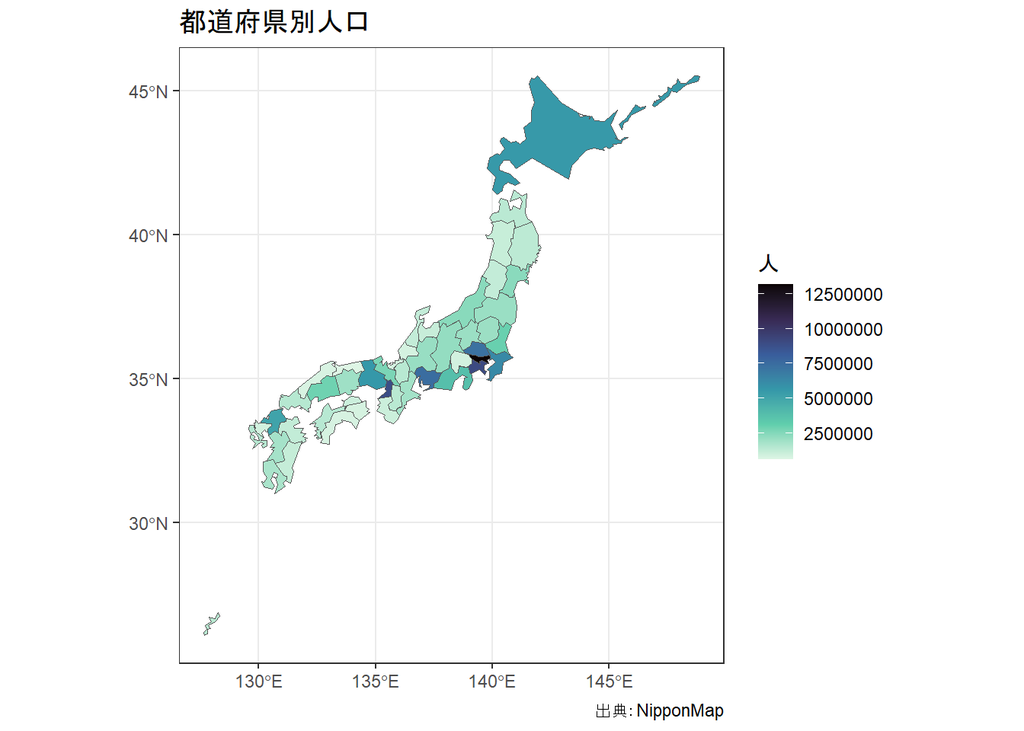

```r
ggplot()+
  geom_sf(data=Nippon_map, aes(fill=population))+
  scale_fill_viridis_c(option="G", direction=-1)+
  labs(fill="人",
       caption="出典：NipponMap")+
  ggtitle("都道府県別人口")+
  theme_bw()
```

**Rによる地理空間データの可視化**

- チュートリアル[ホーム](https://shinichiro-iwata.github.io/geospatial-data-visualization/)
[^1]: [シェープファイル](https://ja.wikipedia.org/wiki/%E3%82%B7%E3%82%A7%E3%83%BC%E3%83%97%E3%83%95%E3%82%A1%E3%82%A4%E3%83%AB)は図形（地物）・属性情報を含む複数のファイルから構成される．拡張子は`.shp`，`.shx`，`.dbf`など．`R`コードには主に`.shp`が出現するが，ファイルから他の拡張子（`.shx`，`.dbf`など）をもつファイルを削除すると，図形・属性情報を表現できなくなる．
[^2]: このように，数値データに応じて色塗りされた地図をコロプレス図（[階級区分図](https://ja.wikipedia.org/wiki/%E9%9A%8E%E7%B4%9A%E5%8C%BA%E5%88%86%E5%9B%B3)）とよぶ．
[^3]: 必要に応じてパッケージをインストール（`install.packages("viridis")`し，library(viridis)で読込．